# individual1

Alicia Hauglie

2/19/2019

```r
data(happy, package="productplots")
head(happy)
```

```
##   id         happy year age    sex       marital         degree
## 1  1 not too happy 1972  23 female never married       bachelor
## 2  2 not too happy 1972  70   male       married lt high school
## 3  3  pretty happy 1972  48 female       married    high school
## 4  4 not too happy 1972  27 female       married       bachelor
## 5  5  pretty happy 1972  61 female       married    high school
## 6  6  pretty happy 1972  26   male never married    high school
##         finrela    health wtssall
## 1       average      good  0.4446
## 2 above average      fair  0.8893
## 3       average excellent  0.8893
## 4       average      good  0.8893
## 5 above average      good  0.8893
## 6 above average      good  0.4446
```

```r
HAPPY <- readRDS("HAPPY.rds")
```

finrela <- opinion of family income polviews <- think of self as liberal or conservative wttsall <- weight variable Inapplicable (IAP) <- respondents who are not asked to answer a specific question

1. Data cleaning: the values “IAP”, “DK” and “NA” all encode missing values. Replace all of these instances by the value NA.

```r
library(dplyr)
```

```r
library(ggplot2)
HAPPY[HAPPY == "IAP"] <- NA
HAPPY[HAPPY == "DK"] <- NA
HAPPY[HAPPY == "NA"] <- NA
```

2. Check the type of the variable and cast into the right type (factor variable for categorical variables). For age, change “89 OR OLDER” to 89 and assume the variable should be numeric. (Hint: see ?as.character and ?as.numeric)

```r
HAPPY <- HAPPY %>% mutate_if(is.character, as.factor) %>% mutate(AGE = recode(AGE, "89 OR OLDER" = "89")) %>% mutate(AGE = as.numeric(levels(AGE)[AGE]))
str(HAPPY$AGE)
```

```
##  num [1:62466] 23 70 48 27 61 26 28 27 21 30 ...
```

3. Bring all levels of factors into a sensible order. For marital you could e.g. order the levels according to average age.

```r
HAPPY <- HAPPY %>% mutate(MARITAL = factor(MARITAL, levels = c("NEVER MARRIED", "MARRIED", "SEPARATED", "DIVORCED", "WIDOWED"))) %>% arrange(desc(MARITAL))

HAPPY <- HAPPY %>% mutate(HAPPY = factor(HAPPY, levels = c("NOT TOO HAPPY", "PRETTY HAPPY", "VERY HAPPY"))) %>% arrange(desc(HAPPY))

HAPPY <- HAPPY %>% mutate(DEGREE = factor(DEGREE, levels = c("LT HIGH SCHOOL", "HIGH SCHOOL", "JUNIOR COLLEGE", "BACHELOR", "GRADUATE"))) %>% arrange(desc(DEGREE))

HAPPY <- HAPPY %>% mutate(FINRELA = factor(FINRELA, levels = c("FAR BELOW AVERAGE", "BELOW AVERAGE", "AVERAGE", "ABOVE AVERAGE", "FAR ABOVE AVERAGE"))) %>% arrange(desc(FINRELA))

HAPPY <- HAPPY %>% mutate(HEALTH = factor(HEALTH, levels = c("POOR", "FAIR", "GOOD", "EXCELLENT"))) %>% arrange(desc(HEALTH))

HAPPY <- HAPPY %>% mutate(PARTYID = factor(PARTYID, levels = c("STRONG DEMOCRAT", "NOT STR DEMOCRAT", "IND,NEAR DEM", "INDEPENDENT", "IND,NEAR REP", "NOT STR REPUBLICAN", "STRONG REPUBLICAN", "OTHER PARTY"))) %>% arrange(desc(PARTYID))

HAPPY <- HAPPY %>% mutate(POLVIEWS = factor(POLVIEWS, levels = c("EXTREMELY LIBERAL", "LIBERAL", "SLIGHTLY LIBERAL", "MODERATE", "SLIGHTLY CONSERVATIVE", "CONSERVATIVE", "EXTRMLY CONSERVATIVE"))) %>% arrange(desc(POLVIEWS))
```

**PART TWO** 1. Investigate the distributions of 2 different variables.

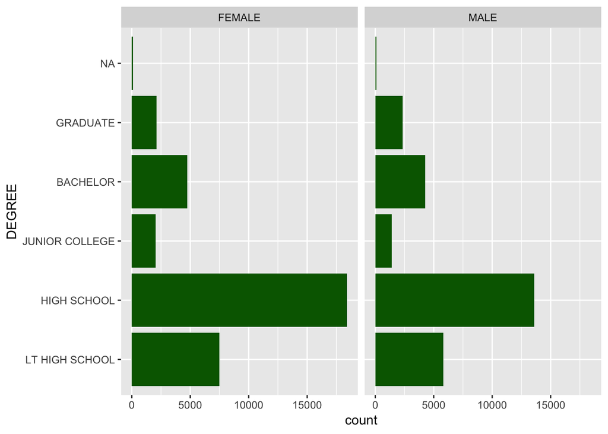

```r
ggplot(data=HAPPY, aes(x=DEGREE))+geom_bar(fill="darkgreen")+facet_wrap(~SEX)+coord_flip()
```

this shows us the distribution of education between the sexes.

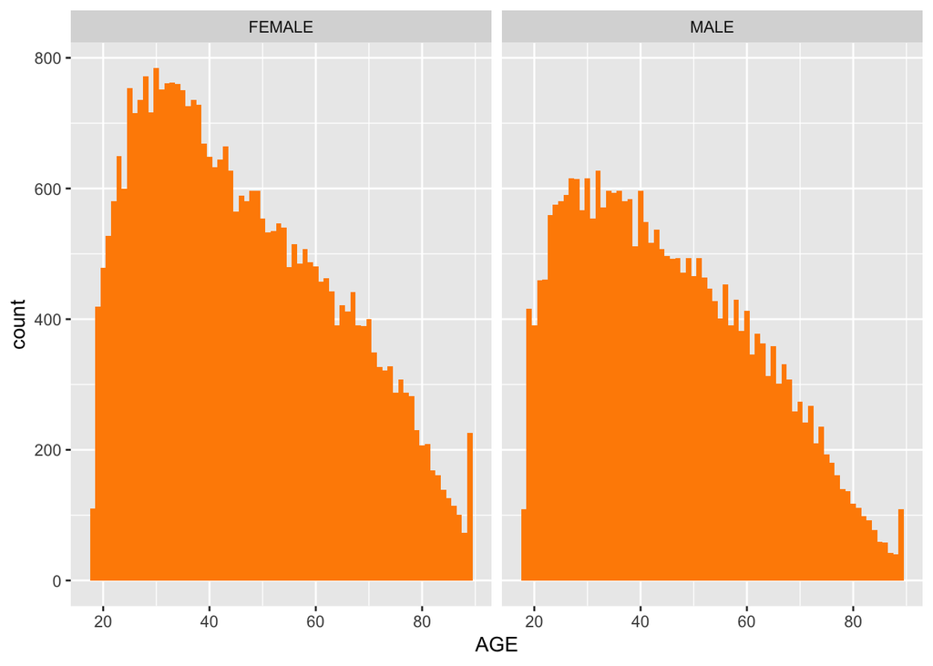

```r
ggplot(data=HAPPY, aes(x=AGE))+geom_histogram(binwidth=1, fill="darkorange")+facet_wrap(~SEX)
```

this shows us the age distribution between the sexes, it also shows that more women took this survey than men.

2. Investigate the relationship between happiness and three other variables in the data.

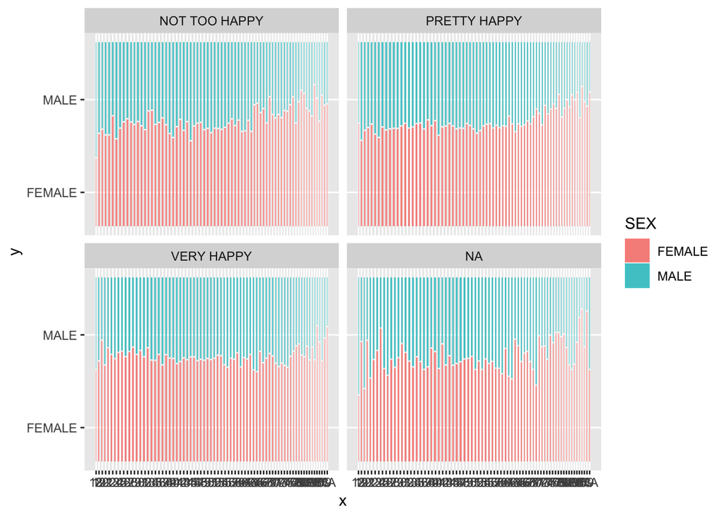

```r
library(ggmosaic)
ggplot(data=HAPPY)+geom_mosaic(aes(x=product(AGE),fill=SEX))+facet_wrap(HAPPY$HAPPY)
```

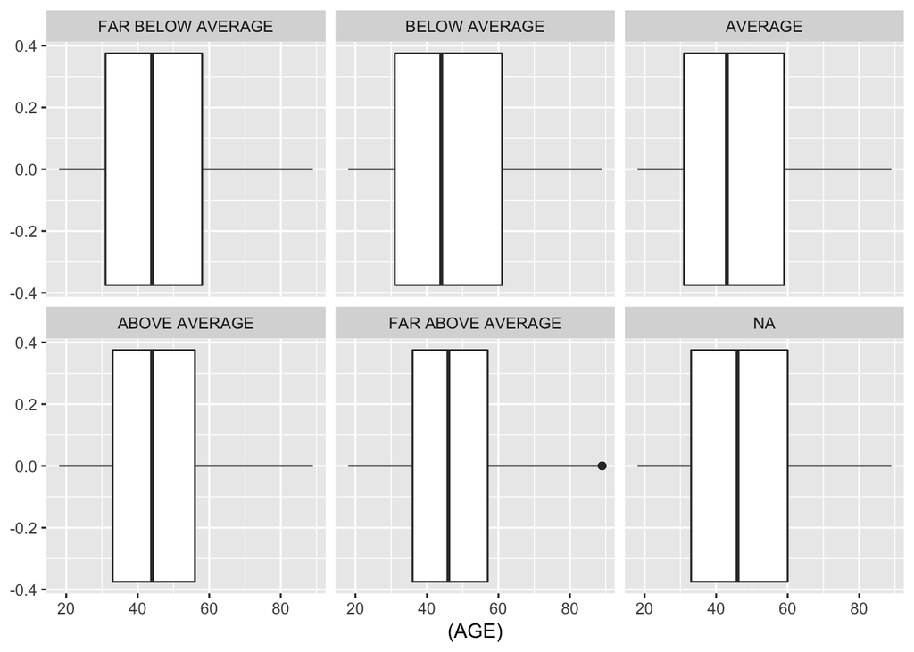

```r
ggplot(data=HAPPY, aes(y=(AGE)))+geom_boxplot()+facet_wrap(HAPPY$FINRELA)+coord_flip()
```

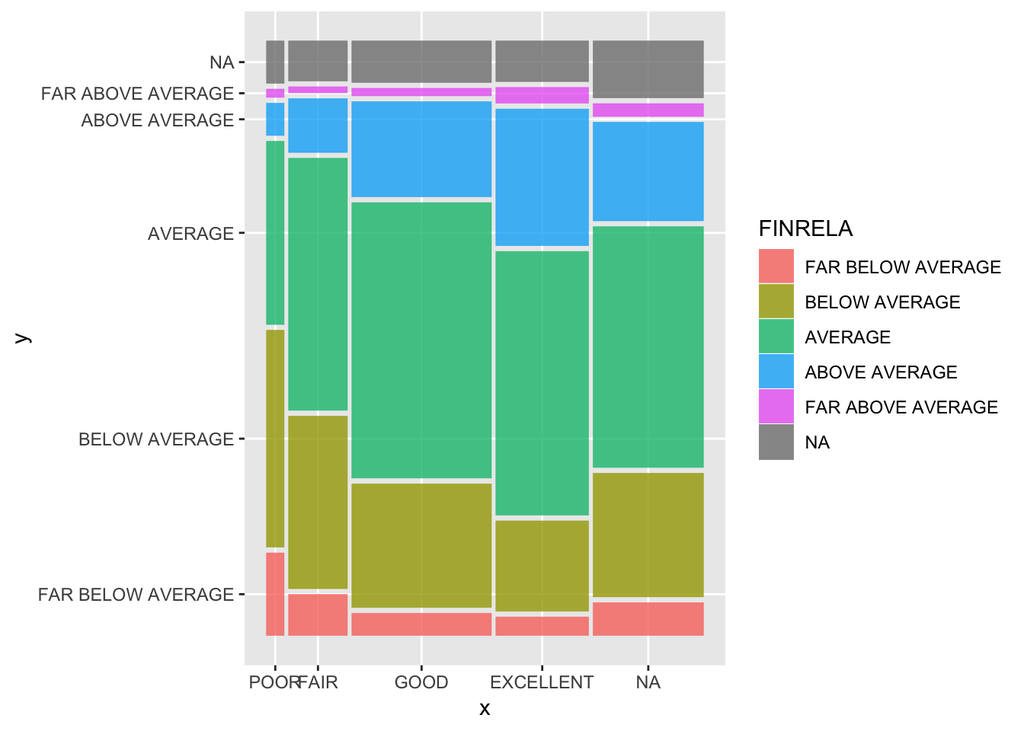

```r
library(ggmosaic)
ggplot(data=HAPPY)+geom_mosaic(aes(x=product(HEALTH),fill=FINRELA))
```

3. What do you learn from the data set? Write one or two paragraphs to describe.

I feel like this dataset was a bit outdated, the degree distributions would be very different now with more people having attended college. Many of the variables seemed to have no correlation to happiness. I would have liked a more equal number of male and and female respondents. The biggest connection I found was between FINRELA and HEALTH, in which people who were poorer tended to respond with only fair or good health, whereas people who were of better finiancial standing were way more likely to respond with EXCELLENT health. I didn’t really understand why we had both PARTYID and POLVIEWS in the survey, I feel like this information was a bit redundant except maybe if you were to pick out a few outliers who identified as STRONG DEMOCRAT but had CONSERVATIVE polviews. This data was a bit hard to work with considering most of the variables were categorical, I tried to use examples from the Titanic dataset to help me when creating visuals but I found it a bit difficult.